# Music Symbol Detection

[figure not shown]

Optical music recognition is the task of converting the image data of sheet music into a digital format, in order to digitally manipulate or work on the music given in paper. Object detection can be used for detecting notes or other symbols in the sheet music, which can be used to help recognize the positional relationship between the symbols in an image. In this project, we explored object detection in a dataset containing sheet music, using the MUSCIMA++ dataset and the Faster-RCNN model.

## Introduction

Recognizing and converting sheet music is a very useful task for quickly working with a large amount of music (without having to input it by hand), but even though there isn’t a lack of research in the area, there are not many solutions available (and most popular solutions are quite old). Thus, we wanted to learn about this data and how deep learning is used to detect symbols in sheet music. We used Faster-RCNN for an object detection task for this, since object detection can be used as an important part of understanding sheet music.

[video not shown]

[Open in colab](https://colab.research.google.com/drive/1lEPji-B_yPgXL3DHXqSiKiGcS91Ma0UJ). [View Presentation](https://docs.google.com/presentation/d/1w3q-eJXMujxYsdM7H8aRY978ZXgC8QuDvoPYwoEPhFU/edit?usp=sharing). [Prediction Demo using Test Images](https://youtu.be/oj4ZwiRbF1g)

## Related Work & Motivation

There are currently many datasets available for different tasks on many levels concerning optical music recognition. End-to-end recognition is the most high-level task, which consists of converting an image to a midi file (or a similar file for musical notation). Many datasets simply focus on symbol classification and object detection/image segmentation. We have chosen our dataset from a list given here: (https://github.com/apacha/OMR-Datasets)

From this list, we selected MUSCIMA++ because it contained a large collection of handwritten symbols with bounding box predictions, making it an ideal dataset for object detection.

A paper very similar to what we wanted to achieve was Handwritten Music Object Detection: Open Issues and Baseline Results (https://ieeexplore.ieee.org/document/8395189), which used Faster RCNN, R-FCN and other models in the same MUSCIMA++ dataset that we had. The Faster RCNN model resulted in the highest accuracy in that paper, and we wanted to try this model ourselves on MUSCIMA++ as well.

## Model: Faster RCNN

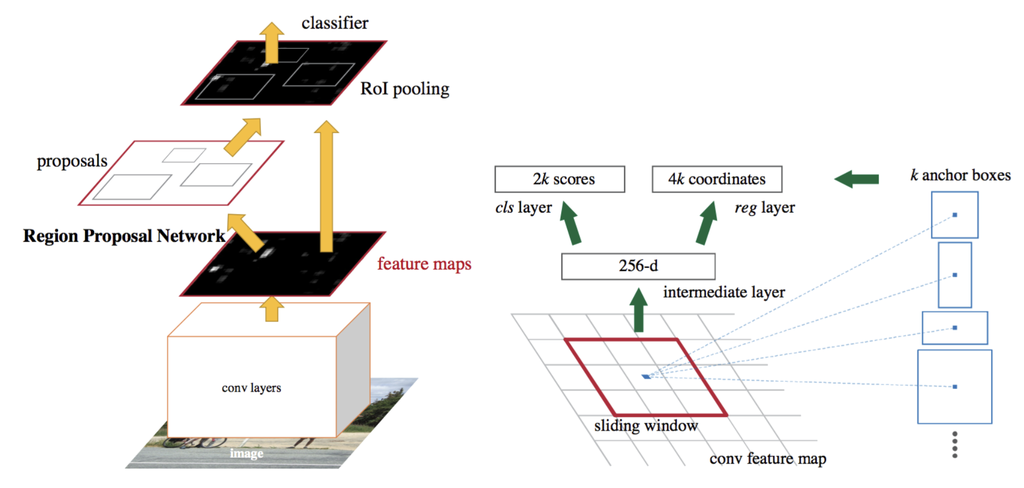

The Faster RCNN model consists of a Region Proposal Network (RPN), which itself uses a CNN (pretrained on an image classification task)

# MUSCIMA++ dataset

[Muscima++](https://apacha.github.io/OMR-Datasets/#muscima) is a dataset of handwritten music notation for musical symbol detection that is based on the MUSCIMA dataset. It contains 91255 symbols, consisting of both notation primitives and higher-level notation objects, such as key signatures or time signatures. There are 23352 notes in the dataset, of which 21356 have a full notehead, 1648 have an empty notehead, and 348 are grace notes. Composite objects, such as notes, are captured through explicitly annotated relationships of the notation primitives (noteheads, stems, beams, accidentalnote, slur).

As we look for build a deep netural network to identify music symbol from handwritten sheet, this dataset provides 140 high quality handwritten images. These images are of different size 1200x2000 to 2000 x 3500.

Annotations of each symbol is available in xml documents. These annotations were used to create bounding box for each symbol in dataset.

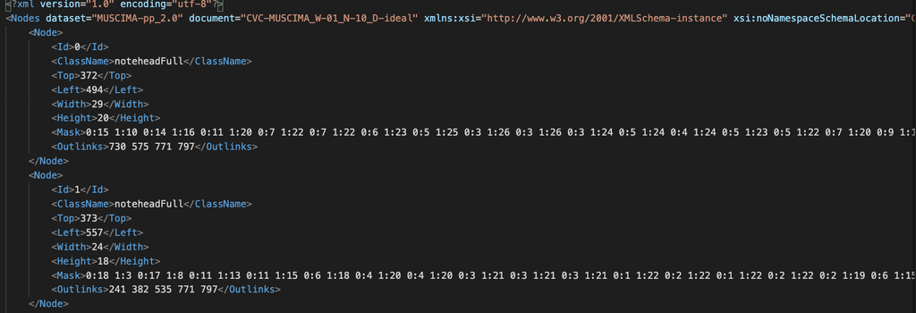

Bounding box top, left, height, width are used to identify each symbol. Mask is a 0-1 length encoded string representation of each box.  
How annotation is done: https://muscimarker.readthedocs.io/en/develop/instructions.html

For each annonated objects in an image, it provided both bouding box and pixel mask that defines exactly which pixel within the box belongs to symbol

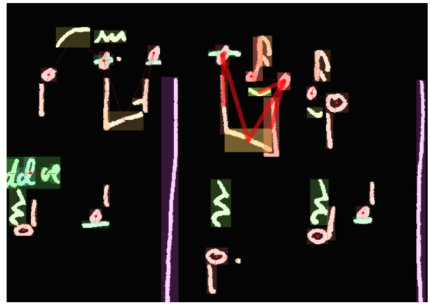

## Dowload and setup utils

```python
#@title
from IPython.core.interactiveshell import InteractiveShell
InteractiveShell.ast_node_interactivity = "all"
```

```python
#@title
from google.colab import drive
drive.mount('/gdrive/')
!ls /gdrive
```

```python
# install xmlschema to parse annotation xml
!pip install xmlschema
```

### Download utils for model training

```python
%%shell

# Download TorchVision repo to use some files from
# references/detection
git clone https://github.com/pytorch/vision.git
git stash push --keep-index
cd vision
git checkout v0.3.0

cp references/detection/utils.py ../
cp references/detection/transforms.py ../. # custom transforms for coco.
cp references/detection/coco_eval.py ../
cp references/detection/engine.py ../
cp references/detection/coco_utils.py ../
```

### Download data

Muscima++ data is splitted into train, test and validation. Download it form git repo https://github.com/aftabalam01/aftabalam01.github.io.git

```python
%%shell
# have downloaded images, annonations and splitted into train, validation and test then created archive locally and updated in google drive
rm -f aftabalam01.github.io/muscima_data.tar.gz
git clone https://github.com/aftabalam01/aftabalam01.github.io.git
tar -xvf aftabalam01.github.io/muscima_data.tar.gz
ls -lrt
```

```python
#@title
# test code
# covert annotation to dict objects
data_root = 'data/muscima_pp/v2.0'
import xmlschema
my_schema = xmlschema.XMLSchema(f'{data_root}/data/annotations/CVC-MUSCIMA_Schema.xsd')
my_schema.is_valid(f'{data_root}/data/annotations/CVC-MUSCIMA_W-10_N-18_D-ideal.xml')
from pprint import pprint
dictobj = my_schema.to_dict(f'{data_root}/data/annotations/CVC-MUSCIMA_W-10_N-18_D-ideal.xml')
pprint(dictobj['Node'][0])
```

### Validate dataset

```python
#@title
# get top 20 classes in dataset
import pandas as pd
import os
df = pd.DataFrame()
for f in os.listdir(f'{data_root}/data/annotations/'):
  dictobj = my_schema.to_dict(f'{data_root}/data/annotations/{f}')
  try:
    df1 = pd.DataFrame(data=dictobj['Node'])
    df = df.append(df1)
  except:
    #print(dictobj)
top_df = df.groupby(['ClassName']).count()
pd.DataFrame(top_df['Id'].sort_values(ascending=False)).head(30)
```

```python
#@title
# testcode
import pandas as pd
classschema = xmlschema.XMLSchema(f'{data_root}/specifications/NodeClasses_Schema.xsd')
ml_classes = classschema.to_dict(f'{data_root}/specifications/mff-muscima-mlclasses-annot.xml')
df = pd.DataFrame(ml_classes['NodeClass'])
df
df.loc[df['Name'] == 'noteheadHalf']
df.loc[df['Name'] == 'noteheadHalf']['Id'].to_numpy()[0]
print()
df.count()
```

## Dataset class

Custom transform classes to covnert different size images in same size images, data augmentation using randomcrop and rescaling of images

```python
class RandomCrop(object):
    """Crop randomly the image in a sample.

    Args:
        output_size (tuple or int): Desired output size. If int, square crop
            is made.
    """

    def __init__(self, output_size):
        assert isinstance(output_size, (int, tuple))
        if isinstance(output_size, int):
            self.output_size = (output_size, output_size)
        else:
            assert len(output_size) == 2
            self.output_size = output_size

    def __call__(self, image, targets):
        # take current targets
        o_boxes,o_labels,o_area,o_masks,image_id, iscrowd = targets['boxes'],targets['labels'],targets['area'],targets['masks'], targets['image_id'],targets["iscrowd"]

        _,h, w = image.shape
        new_h, new_w = self.output_size

        top = np.random.randint(0, h - new_h)
        left = np.random.randint(0, w - new_w)
        #print(f'new image x:y {left}:{top}')

        image = image[:,top: top + new_h,
                      left: left + new_w]
        _,o_h,o_w = image.shape
        boxes = [[0,0,o_w,o_h]]
        labels = [0]
        box_area = [o_h*o_w]
        masks=[[[0]]]
        num_objs = o_boxes.size(0)
        target={}
        if num_objs:
          for idx in range(num_objs):
              box = o_boxes[idx]
              x1,y1,x2,y2 = box.tolist()
              # remove boxes that are in within crop area
              if x1>left and y1>top and x2<left + new_w and y2< top + new_h :
                new_box = [x1-left,y1-top,x2-left,y2-top]
                boxes.append(new_box)
                labels.append(o_labels[idx])
                masks.append(o_masks[idx].tolist())
                box_area.append(o_area[idx].tolist())

        boxes = torch.as_tensor(boxes, dtype=torch.float32)
        labels = torch.as_tensor(labels, dtype=torch.int64)
        masks = masks_tensor(masks)
        target["boxes"] = boxes #torch.as_tensor(boxes, dtype=torch.int64)
        target["labels"] = labels #torch.as_tensor(labels, dtype=torch.int64)
        target["masks"] = torch.as_tensor(masks, dtype=torch.uint8)
        target["image_id"] = torch.as_tensor(image_id, dtype=torch.int64)
        target["area"] = torch.as_tensor(box_area, dtype=torch.int64)
        iscrowd = torch.zeros((target["boxes"].size(0),), dtype=torch.int64)
        target["iscrowd"] = torch.as_tensor(iscrowd, dtype=torch.int64)

        return image, target
```

```python
from torchvision.transforms import functional as F
class ToTensor(object):
    """Convert ndarrays in sample to Tensors."""

    def __call__(self, image, targets):

        image = F.to_tensor(image)
        return image, targets
```

```python
import torch.nn.functional as Fi
class Rescale(object):
    """Rescale the image in a sample to a given size.

    Args:
        output_size (tuple or int): Desired output size. If tuple, output is
            matched to output_size. If int, smaller of image edges is matched
            to output_size keeping aspect ratio the same.
    """

    def __init__(self, output_size):
        assert isinstance(output_size, (int, tuple))
        self.output_size = output_size

    def __call__(self, image, targets):
        # take current targets
        o_boxes,o_labels,o_area,o_masks,image_id, iscrowd = targets['boxes'],targets['labels'],targets['area'],targets['masks'], targets['image_id'],targets["iscrowd"]

        N,h, w = image.shape
        if isinstance(self.output_size, int):
            if h > w:
                new_h, new_w = self.output_size * h / w, self.output_size
            else:
                new_h, new_w = self.output_size, self.output_size * w / h
        else:
            new_h, new_w = self.output_size

        new_h, new_w = int(new_h), int(new_w)
        img = Fi.interpolate(image.unsqueeze(0), size=(new_h,new_w),mode='bilinear',align_corners=True)
        img = img[0] # remove batch added by interpolate
        boxes = [[0,0,new_w,new_h]]
        labels = [0]
        box_area = [new_w*new_h]
        masks=[[[0]]]
        num_objs = o_boxes.size(0)
        target={}
        for idx in range(num_objs):
            box = o_boxes[idx]
            x1,y1,x2,y2 = box.tolist()
            b_h = (y2-y1)*new_h/h
            b_w = (x2-x1)*new_w/w
            new_box = [x1*new_w/w,y1*new_h/h,x1*new_w/w + b_w ,y1*new_h/h+b_h]
            boxes.append(new_box)
            labels.append(o_labels[idx])
            masks.append(o_masks[idx].tolist())
            box_area.append(b_h*b_w) # new box width * height
        # convert everything into a torch.Tensor
        boxes = torch.as_tensor(boxes, dtype=torch.float32)
        labels = torch.as_tensor(labels, dtype=torch.int64)
        masks = masks_tensor(masks)
        area = torch.as_tensor(box_area, dtype=torch.float32)

        target["boxes"] = boxes  #torch.as_tensor(boxes, dtype=torch.int64)
        target["labels"] = labels #torch.as_tensor(labels, dtype=torch.int64)
        target["masks"] = torch.as_tensor(masks, dtype=torch.uint8)
        target["image_id"] = torch.as_tensor(image_id, dtype=torch.int64)
        target["area"] = torch.as_tensor(box_area, dtype=torch.int64)
        iscrowd = torch.zeros((target["boxes"].size(0),), dtype=torch.int64)
        target["iscrowd"] = torch.as_tensor(iscrowd, dtype=torch.int64)
        return img, target
```

```python
class Compose(object):
    def __init__(self, transforms):
        self.transforms = transforms

    def __call__(self, image, target):
        for t in self.transforms:
            image, target = t(image, target)
        return image, target

def get_transform(transform):
    transforms = []
    # converts the image, a PIL image, into a PyTorch Tensor
    transforms.append(ToTensor())
    if transform:
        # during training, randomly flip the training images
        # and ground-truth for data augmentation
        #transforms.append(RandomCrop((600,800)))
        transforms.append(Rescale((600,800)))
    return Compose(transforms)
```

#### Muscima dataset

```python
# set up muscima dataset
# return PILImage and target tensor as mentions in tutorial https://pytorch.org/tutorials/intermediate/torchvision_tutorial.html
# https://colab.research.google.com/github/pytorch/vision/blob/temp-tutorial/tutorials/torchvision_finetuning_instance_segmentation.ipynb#scrollTo=lWOhcsir9Ahx
# https://muscima.readthedocs.io/en/latest/muscima.io.html


import os
import xmlschema
import numpy as np
import torch
import pandas as pd
from PIL import Image
#from torchvision import transforms
data_root = 'data/muscima_pp/v2.0'
with open('data/training_validation_test/training.txt') as f:
    train_imgs = f.read().splitlines()
with open('data/training_validation_test/test.txt') as f:
    test_imgs = f.read().splitlines()
with open('data/training_validation_test/validation.txt') as f:
    validation_imgs = f.read().splitlines()
images_dict = {'train':train_imgs,'test':test_imgs,'validation':validation_imgs}
# classes that we need to detect. Selecting top 10
#top_classes = ['','stem','noteheadFull','legerLine','beam','staffSpace','staffLine','barline','measureSeparator','slur','accidentalSharp']
top_classes = ['','stem','noteheadFull','accidentalSharp','slur']
#top_classes = ['','noteheadFull','stem']
NUM_CLASSESS= len(top_classes) # 1 for background
COLORS = ['r','r','b','g','c','m','y','k','w']
# b: blue
# g: green
# r: red
# c: cyan
# m: magenta
# y: yellow
# k: black
# w: white

# helper function to decode length encoded masks
def decode_runlengthencode_array(x,width,height):
  """
  length encode of mask
  x = 0:15 1:10 0:14 1:16 0:11 1:20 0:7 1:22 0:7 1:22 0:6 1:23 0:5 1:25 0:3 1:26 0:3 1:26 0:3 1:24 0:5 1:24 0:4 1:24 0:5 1:23 0:5 1:22 0:7 1:20 0:9 1:19 0:9 1:17 0:13 1:14 0:16 1:10 0:19 1:5 0:22
  """
  out = []
  x = x.split(" ")
  for i in x:
    cnt = i.split(":")
    arr = [int(cnt[0])] * int(cnt[1])
    out = out+ arr
  #print(f'{width}:{height}')
  return np.asarray(out).reshape(width,height)
def masks_tensor(masks):
  """
  since masks of each node are not of equal dim, we need to make it of equal dim in order to convert it in tensor
  """
  ret_array = []
  if masks:
    max_cols = max([len(row) for mask in masks for row in mask])
    max_rows = max([len(mask) for mask in masks])
    #print(f'required dim {max_rows}:{max_cols}')

    for mask in masks:
      #print(f'before reshape: {mask.shape}')
      mask = np.resize(mask,(max_rows, max_cols))
      #print(f'after reshape: {mask.shape}')

      ret_array = ret_array + [mask]
  else:
    ret_array = torch.zeros((1,1,1),dtype=torch.uint8)
  return torch.as_tensor(np.array(ret_array), dtype=torch.uint8)

class MuscimaDataset(torch.utils.data.Dataset):
    def __init__(self, root=data_root, transforms=get_transform(transform=False),dataset_type='train'):
        self.data_root = root
        self.transforms = transforms
        # load all image files, sorting them to
        # ensure that they are aligned
        self.imgs = images_dict[dataset_type]
        self.xmlschema = xmlschema.XMLSchema(f'{self.data_root}/data/annotations/CVC-MUSCIMA_Schema.xsd')
        self.nodeclass = NodeClass(root=self.data_root)


    def __getitem__(self, idx):
        # load images ad masks
        img_path = f'{self.data_root}/data/images/{self.imgs[idx]}.png'
        img = Image.open(img_path)
        ann_path = f'{self.data_root}/data/annotations/{self.imgs[idx]}.xml'
        dictobj = self.xmlschema.to_dict(ann_path)
        w,h = img.size
        boxes = [[0,0,w,h]]
        classnames = [0]
        box_areas = [h*w]
        masks=[[[0]]]
        # get bounding box coordinates for each mask
        num_objs = len(dictobj['Node'])
        for node in dictobj['Node']:
          classname = node['ClassName']
          if classname in top_classes:
            height = node['Height'] # columns
            width = node['Width'] # rows
            top = node['Top']
            left = node['Left']
            id = node['Id']
            masks.append(decode_runlengthencode_array(node['Mask'],width,height))# 0,1 2D array
            boxes.append([left,top,left+width,top+height]) # boxes.append([x0,y0,xmax,ymax])
            # get class id from dataframe
            try:
              classnames.append(top_classes.index(classname))
            except:
              print(classname)
            box_areas.append(height*width)

        # convert everything into a torch.Tensor
        boxes = torch.as_tensor(boxes, dtype=torch.float32)
        labels = torch.as_tensor(classnames, dtype=torch.int64)
        masks = masks_tensor(masks)
        image_id = torch.tensor([idx])
        area = torch.as_tensor(box_areas, dtype=torch.float32)
        # suppose all instances are not crowd
        iscrowd = torch.zeros((boxes.size(0),), dtype=torch.int64)
        target = {}
        target["boxes"] = boxes
        target["labels"] = labels
        target["masks"] = masks
        target["image_id"] = image_id
        target["area"] = area
        target["iscrowd"] = iscrowd

        if self.transforms is not None:
            img, target = self.transforms(img, target)

        return img, target

    def __len__(self):
        return len(self.imgs)

class NodeClass(object):
  def __init__(self,root=data_root):
    self.data_root=root
    classschema = xmlschema.XMLSchema(f'{self.data_root}/specifications/NodeClasses_Schema.xsd')
    self.df_classes = pd.DataFrame(classschema.to_dict(f'{self.data_root}/specifications/mff-muscima-mlclasses-annot.xml')['NodeClass'])

  def get_id(self, classname):
    return self.df_classes.loc[self.df_classes['Name']==classname]['Id'].to_numpy()[0]

  def get_name(self,id):
    return self.df_classes.loc[self.df_classes['Id']==id]['Name'].to_numpy()[0]
```

```python
#@title
# test code
x = '0:15 1:10 0:14 1:16 0:11 1:20 0:7 1:22 0:7 1:22 0:6 1:23 0:5 1:25 0:3 1:26 0:3 1:26 0:3 1:24 0:5 1:24 0:4 1:24 0:5 1:23 0:5 1:22 0:7 1:20 0:9 1:19 0:9 1:17 0:13 1:14 0:16 1:10 0:19 1:5 0:22'
out = decode_runlengthencode_array(x,29,20)
out.shape
nodeclass = NodeClass()
print()
nodeclass.get_name(0)
print(nodeclass.get_id(nodeclass.get_name(10)))
```

#### Function to draw images with symbols

```python
import matplotlib.pyplot as plt
import matplotlib.patches as patches
from PIL import Image
import numpy as np

def draw_image(img, target):
  x= img.size()[1]
  y= img.size()[2]
  im = img.view(x,y)

  # Create figure and axes
  fig,ax = plt.subplots(1,figsize=(20,20))

  # Display the image
  ax.imshow(im,cmap='binary_r')

  # Create a Rectangle patch
  num_objs = target['boxes'].size(0)
  for idx in range(num_objs):
    x1,y1,x2,y2 = target['boxes'][idx].tolist()
    label = target['labels'][idx].tolist()
    # calculate width and height of the box
    width, height = x2 - x1, y2 - y1
    # create the shape
    rect = patches.Rectangle((x1, y1), width, height, fill=False, linewidth=1,edgecolor=COLORS[label],facecolor='none')
    # Add the patch to the Axes
    ax.add_patch(rect)

  plt.show()
```

Sample image display

```python
dataset = MuscimaDataset(dataset_type='test',transforms=get_transform(transform=False))
img, target = dataset[10]
print("origional image")
draw_image(img, target)
dataset = MuscimaDataset(dataset_type='test',transforms=get_transform(transform=True))
img, target = dataset[10]
print("scaled image")
draw_image(img, target)
```

[output not shown]

```python
import torchvision
from torchvision.models.detection.faster_rcnn import FastRCNNPredictor

# load a model pre-trained pre-trained on COCO
model = torchvision.models.detection.fasterrcnn_resnet50_fpn(pretrained=True)

# replace the classifier with a new one, that has
# num_classes which is user-defined
num_classes = NUM_CLASSESS  # 1 class (person) + background
# get number of input features for the classifier
in_features = model.roi_heads.box_predictor.cls_score.in_features
# replace the pre-trained head with a new one
model.roi_heads.box_predictor = FastRCNNPredictor(in_features, num_classes)
```

```python
import torchvision
from torchvision.models.detection import FasterRCNN
from torchvision.models.detection.rpn import AnchorGenerator

# load a pre-trained model for classification and return
# only the features
backbone = torchvision.models.mobilenet_v2(pretrained=True).features
# FasterRCNN needs to know the number of
# output channels in a backbone. For mobilenet_v2, it's 1280
# so we need to add it here
backbone.out_channels = 1280

# let's make the RPN generate 5 x 3 anchors per spatial
# location, with 5 different sizes and 3 different aspect
# ratios. We have a Tuple[Tuple[int]] because each feature
# map could potentially have different sizes and
# aspect ratios
anchor_generator = AnchorGenerator(sizes=((32, 64, 128, 256, 512),),
                                   aspect_ratios=((0.5, 1.0, 2.0),))

# let's define what are the feature maps that we will
# use to perform the region of interest cropping, as well as
# the size of the crop after rescaling.
# if your backbone returns a Tensor, featmap_names is expected to
# be [0]. More generally, the backbone should return an
# OrderedDict[Tensor], and in featmap_names you can choose which
# feature maps to use.
roi_pooler = torchvision.ops.MultiScaleRoIAlign(featmap_names=[0],
                                                output_size=7,
                                                sampling_ratio=2)

# put the pieces together inside a FasterRCNN model
model = FasterRCNN(backbone,
                   num_classes=NUM_CLASSESS,
                   rpn_anchor_generator=anchor_generator,
                   box_roi_pool=roi_pooler)
```

```python
import torchvision
from torchvision.models.detection.faster_rcnn import FastRCNNPredictor
from torchvision.models.detection.mask_rcnn import MaskRCNNPredictor


def get_instance_segmentation_model(num_classes):
    # load an instance segmentation model pre-trained on COCO
    model = torchvision.models.detection.maskrcnn_resnet50_fpn(pretrained=True)

    # get the number of input features for the classifier
    in_features = model.roi_heads.box_predictor.cls_score.in_features
    # replace the pre-trained head with a new one
    model.roi_heads.box_predictor = FastRCNNPredictor(in_features, num_classes)

    # now get the number of input features for the mask classifier
    in_features_mask = model.roi_heads.mask_predictor.conv5_mask.in_channels
    hidden_layer = 256
    # and replace the mask predictor with a new one
    model.roi_heads.mask_predictor = MaskRCNNPredictor(in_features_mask,
                                                       hidden_layer,
                                                       num_classes)

    return model
```

### Dataloader

```python
# use our dataset and defined transformations
import utils
dataset = MuscimaDataset(dataset_type='train',transforms=get_transform(transform=True))
dataset_valid = MuscimaDataset(dataset_type='validation',transforms=get_transform(transform=True))
dataset_test = MuscimaDataset(dataset_type='test',transforms=get_transform(transform=False))

# split the dataset in train and test set
torch.manual_seed(1)

data_loader = torch.utils.data.DataLoader(
    dataset, batch_size=5, shuffle=True, num_workers=4,
    collate_fn=utils.collate_fn)
data_loader_valid = torch.utils.data.DataLoader(
    dataset_valid, batch_size=2, shuffle=False, num_workers=4,
    collate_fn=utils.collate_fn)
data_loader_test = torch.utils.data.DataLoader(
    dataset_test, batch_size=1, shuffle=False, num_workers=4,
    collate_fn=utils.collate_fn)
```